# Folha 9 — **Resolução**

08 dezembro 2025

## Exercício 1 – Estimação pontual e propriedades

Temos:

```r
dados_ex1 <- c(6.5, 7.0, 5.8, 8.2, 6.9, 7.5, 5.2, 6.1, 7.8, 6.3, 5.9, 7.1)
length(dados_ex1)  # 12
```

```
## [1] 12
```

### 1(a) Estimadores usuais

- Para a **média populacional** $\mu$:

$$\hat\mu = \bar X = \frac{1}{n}\sum_{i=1}^n X_i.$$

- Para a **variância populacional** $\sigma^2$ (estimador não-enviesado):

$$S^2 = \frac{1}{n-1}\sum_{i=1}^n (X_i - \bar X)^2.$$

### 1(b) Expressões explícitas

Com uma amostra $X_1,\dots,X_n$:

- Média amostral:

$$\bar X = \frac{X_1 + X_2 + \cdots + X_n}{n}.$$

- Variância amostral:

$$S^2 = \frac{1}{n-1}\left[(X_1-\bar X)^2 + \cdots + (X_n-\bar
X)^2\right].$$

### 1(c) Média e variância amostrais em R

```r
mean(dados_ex1)
```

```
## [1] 6.691667
```

```r
var(dados_ex1)
```

```
## [1] 0.7862879
```

Resultados (aprox.):

- $\bar x \approx 6.6917$ horas
- $s^2 \approx 0.7863$ (variância amostral)

Isto bate exatamente com as fórmulas da alínea (b): `mean` calcula $\bar X$ e `var` calcula a variância com denominador $n-1$.

### 2(a) Não-enviesado

Um estimador $\hat\theta$ é **não-enviesado** (não-enviesado) para o parâmetro $\theta$ se:

$$\mathbb{E}[\hat\theta] = \theta.$$

Em palavras: **em média**, se repetíssemos a experiência muitas vezes, a média das estimativas coincidiria com o verdadeiro valor do parâmetro; o estimador não tende sistematicamente a sobrestimar nem a subestimar.

### 2(b) Consistência

Um estimador $\hat\theta_n$ é **consistente** para $\theta$ se, quando o tamanho amostral $n$ cresce, $\hat\theta_n$ se aproxima de $\theta$ com probabilidade cada vez maior.

Formalmente: $\hat\theta_n \to \theta$ em probabilidade, quando $n \to \infty$.

Em palavras: com amostras cada vez maiores, a estimativa aproxima-se do valor verdadeiro.

### 2(c) Porque é que $\bar X$ é um estimador “natural” de $\mu$?

De forma qualitativa:

- $\bar X$ é a **média** dos valores observados – é o resumo mais simples da tendência central.
- Em muitas classes de modelos, sabe-se que $\bar X$ é **não-enviesado** para $\mu$ e **consistente**.
- Além disso, sob condições usuais, é um estimador “eficiente” (tem variância relativamente baixa face a outros estimadores razoáveis).

Por isso, é natural usar a média amostral como estimativa da média populacional.

### 2(d) Mínimo, máximo, média e desvio padrão

Em R:

```r
min(dados_ex1)
```

```
## [1] 5.2
```

```r
max(dados_ex1)
```

```
## [1] 8.2
```

```r
mean(dados_ex1)
```

```
## [1] 6.691667
```

```r
sd(dados_ex1)
```

```
## [1] 0.8867288
```

Resultados (aprox.):

- $\min \approx 5.2$
- $\max \approx 8.2$
- $\bar x \approx 6.69$
- $s \approx 0.89$

Interpretação rápida:

- As horas de sono andam em torno de ~6.7 horas, com dispersão moderada (dp ~0.9).
- Não há valores extremamente afastados, portanto a média parece um resumo razoável.

## Exercício 2 – Intervalos de confiança para a média

### 1(a) Importação e estatísticas descritivas

```r
dados <- read.csv("baterias.csv", header = TRUE, sep = ",")
summary(dados$duracao)
```

```
##    Min. 1st Qu.  Median    Mean 3rd Qu.    Max.
##   84.30   96.05  100.95  101.14  104.40  114.30
```

```r
x_bar <- mean(dados$duracao)
s     <- sd(dados$duracao)
n     <- length(dados$duracao)
x_bar; s; n
```

```
## [1] 101.14
```

```
## [1] 7.77766
```

```
## [1] 20
```

### 2(b) IC para $\mu$ com $\sigma$ desconhecida

Assumindo:

- $X_1,\dots,X_n \sim N(\mu,\sigma^2)$
- $\sigma^2$ **desconhecida**

Usamos a estatística:

$$T = \frac{\bar X - \mu}{S/\sqrt{n}} \sim t_{n-1} \quad \text{sob } H_0.$$

Um IC a 95% para $\mu$ é:

$$\left[
\bar X - t_{n-1;0.975}\frac{S}{\sqrt{n}},
;
\bar X + t_{n-1;0.975}\frac{S}{\sqrt{n}}
\right]$$

onde $t_{n-1;0.975}$ é o quantil da distribuição t de Student com $n-1$ graus de liberdade.

### 2(c) Cálculo do IC em R

```r
t.test(dados$duracao, conf.level = 0.95)
```

```
##
##  One Sample t-test
##
## data:  dados$duracao
## t = 58.155, df = 19, p-value < 2.2e-16
## alternative hypothesis: true mean is not equal to 0
## 95 percent confidence interval:
##   97.49994 104.78006
## sample estimates:
## mean of x
##    101.14
```

A saída dá:

- média amostral,
- intervalo de confiança a 95% para $\mu$,
- estatística t, df e p-valor (para um teste `H0: mu = 0` por omissão).

### 3(e) Efeito de aumentar o tamanho amostral

Mantendo a mesma variabilidade ($\sigma^2$ constante):

- O erro padrão $S/\sqrt{n}$ **diminui** quando $n$ aumenta.
- O comprimento do IC (proporcional a $t_{n-1;0.975} \cdot S/\sqrt{n}$) **encurta**.

Conclusão: com mais observações, o IC é **mais estreito**, refletindo **maior precisão** na estimativa de $\mu$.

## Exercício 3 – IC e teste para uma proporção

Temos:

- $n = 200$ estudantes
- $x = 90$ utilizam transportes públicos.

### 1(a) Proporção amostral

$$\hat p = \frac{x}{n} = \frac{90}{200} = 0.45.$$

### 1(b) IC a 95% para $p$ (aproximação normal)

Fórmula geral (aprox. normal):

$$\hat p \pm z_{1-\alpha/2}\sqrt{\frac{\hat p(1-\hat p)}{n}}.$$

Aqui:

- $\hat p = 0.45$
- $n = 200$
- $\alpha = 0.05$ → $z_{0.975} \approx 1.96$

Erro padrão:

$$\text{EP}(\hat p) = \sqrt{\frac{\hat p(1-\hat p)}{n}}
= \sqrt{\frac{0.45 \times 0.55}{200}}
\approx 0.03518.$$

Margem de erro:

$$1.96 \times 0.03518 \approx 0.06895.$$

IC:

$$0.45 \pm 0.06895 \Rightarrow
(0.381, ; 0.519) \ \text{(aprox.)}.$$

Portanto, um IC a 95% para $p$ é aproximadamente:

$$[0.38,; 0.52].$$

### 1(c) Verificação com `prop.test` em R

```r
sucessos <- 90
n <- 200
prop.test(sucessos, n, correct = FALSE)
```

```
##
##  1-sample proportions test without continuity correction
##
## data:  sucessos out of n, null probability 0.5
## X-squared = 2, df = 1, p-value = 0.1573
## alternative hypothesis: true p is not equal to 0.5
## 95 percent confidence interval:
##  0.3826407 0.5192438
## sample estimates:
##    p
## 0.45
```

O intervalo de confiança devolvido será muito próximo do cálculo manual (pode variar ligeiramente porque `prop.test` usa uma estimação ligeiramente diferente – método de Wilson –, mas os valores serão semelhantes).

### 2(d) Teste de hipótese para $p$

Testar:

$$H_0: p = 0.4 \quad \text{vs} \quad H_1: p \ne 0.4,$$

com $\alpha = 0.05$.

Estatística de teste (normal):

$$Z = \frac{\hat p - p_0}{\sqrt{\frac{p_0(1-p_0)}{n}}}$$

onde $p_0 = 0.4$.

Cálculo:

- $\hat p = 0.45$
- $p_0 = 0.4$
- $n = 200$

$$\text{EP}_0 = \sqrt{\frac{0.4 \times 0.6}{200}}
= \sqrt{\frac{0.24}{200}} = \sqrt{0.0012} \approx 0.03464.$$

$$Z = \frac{0.45 - 0.4}{0.03464} \approx \frac{0.05}{0.03464} \approx
1.44.$$

Sob $H_0$, $Z \sim N(0,1)$. O p-valor (bilateral) é:

$$p\text{-valor} = 2 \times P(Z > 1.44) \approx 2 \times 0.074 \approx
0.148.$$

Logo, $p\text{-valor} \approx 0.15$.

Em R:

```r
p_hat <- 90/200
p0    <- 0.4
n     <- 200

se0   <- sqrt(p0*(1-p0)/n)
Z     <- (p_hat - p0)/se0
Z
```

```
## [1] 1.443376
```

```r
# p-valor bilateral
2 * (1 - pnorm(abs(Z)))
```

```
## [1] 0.1489147
```

### 2(e) Decisão e interpretação

- Com $\alpha = 0.05$ e $p\text{-valor} \approx 0.15 > 0.05$, **não rejeitamos $H_0$**.
- Em termos simples:

> Os dados não fornecem evidência estatisticamente significativa, ao nível de 5%, para concluir que a proporção de estudantes que utilizam transportes públicos é diferente de 40%. A diferença observada (45% vs. 40%) pode ser explicada pela variabilidade amostral.

## Exercício 4 – Inferência na regressão linear simples

### 1(a) Gráfico de dispersão

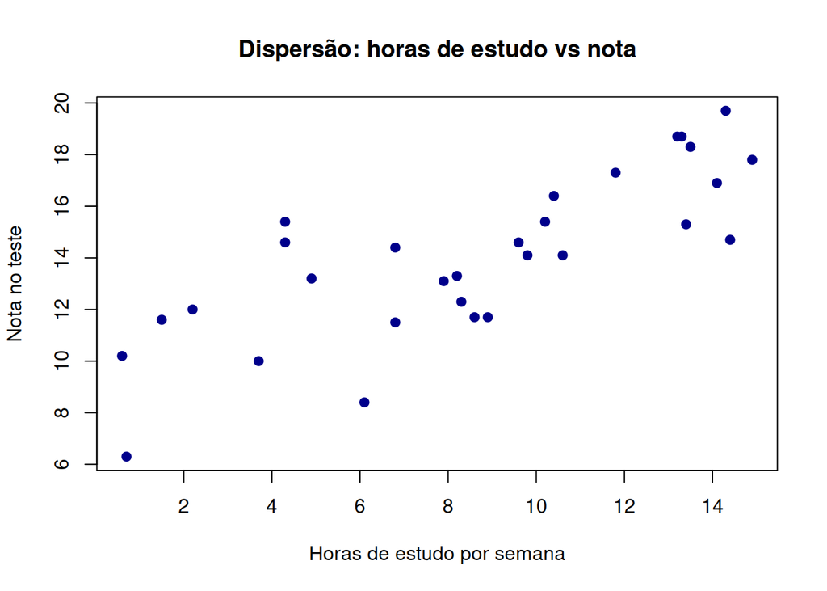

```r
dados2 <- read.csv("estudo_notas.csv", header = TRUE, sep = ",")

plot(dados2$horas_estudo, dados2$nota,
     xlab = "Horas de estudo por semana",
     ylab = "Nota no teste",
     pch = 19, col = "darkblue",
     main = "Dispersão: horas de estudo vs nota")
```

Interpretação esperada (se os dados forem “normais”):

- Pontos tendem a **subir** à medida que as horas de estudo aumentam → indicação de relação positiva entre estudo e nota.

### 1(b) Ajuste do modelo

```r
mod <- lm(nota ~ horas_estudo, data = dados2)
summary(mod)
```

```
##
## Call:
## lm(formula = nota ~ horas_estudo, data = dados2)
##
## Residuals:
##     Min      1Q  Median      3Q     Max
## -4.2324 -1.4609  0.0309  1.4065  3.8027
##
## Coefficients:
##              Estimate Std. Error t value Pr(>|t|)
## (Intercept)   9.12448    0.80946  11.272 6.42e-12 ***
## horas_estudo  0.57507    0.08437   6.816 2.10e-07 ***
## ---
## Signif. codes:  0 '***' 0.001 '**' 0.01 '*' 0.05 '.' 0.1 ' ' 1
##
## Residual standard error: 1.987 on 28 degrees of freedom
## Multiple R-squared:  0.624,  Adjusted R-squared:  0.6105
## F-statistic: 46.46 on 1 and 28 DF,  p-value: 2.097e-07
```

O modelo é:

$$\hat Y = \hat\beta_0 + \hat\beta_1 X$$

onde:

- $\hat\beta_0$ é a interceção (nota esperada quando $X = 0$ horas).
- $\hat\beta_1$ é o declive (variação média esperada na nota quando se aumenta 1 hora de estudo, em média).

`summary(mod)` dá:

- Estimates: `Estimate` (os $\hat\beta$),
- `Std. Error`, `t value`, `Pr(>|t|)` para $\beta_0$ e $\beta_1$,
- $R^2$, etc.

### 2(c) Teste de hipótese para $\beta_1$

Testar:

$$H_0: \beta_1 = 0 \quad \text{vs} \quad H_1: \beta_1 \ne 0.$$

- **$H_0$**: não há relação linear média entre horas de estudo e nota; aumentando as horas de estudo, a nota esperada não muda (no modelo).
- **$H_1$**: existe uma relação linear: as notas tendem a aumentar ou diminuir sistematicamente com as horas de estudo.

Na saída de `summary(mod)`, a linha de `horas_estudo` mostra:

- `Estimate` = $\hat\beta_1$
- `Std. Error` = EP($\hat\beta_1$)
- `t value` = $\hat\beta_1 / \text{EP}(\hat\beta_1)$
- `Pr(>|t|)` = p-valor para o teste $H_0: \beta_1 = 0$.

### 2(d) Decisão a 5% e interpretação

- Se o p-valor para `horas_estudo` for **menor que 0.05**, rejeitamos $H_0$ e concluímos:

> Há evidência estatística, ao nível de 5%, de que existe uma relação linear entre horas de estudo e nota. Em média, alunos que estudam mais horas tendem a obter notas diferentes (tipicamente mais altas, se $\hat\beta_1 > 0$).
- Se o p-valor for **maior que 0.05**, não rejeitamos $H_0$ e concluímos:

> Não há evidência estatisticamente significativa, ao nível de 5%, de que horas de estudo estejam linearmente associadas à nota (no modelo considerado).

### 3(e) Intervalo de confiança a 95% para $\beta_1$

Em R:

```r
confint(mod, level = 0.95)
```

```
##                  2.5 %     97.5 %
## (Intercept)  7.4663881 10.7825788
## horas_estudo 0.4022526  0.7478873
```

Na linha correspondente a `horas_estudo`, obtemos algo como:

$$[\ell, u] = [\text{limite inferior}, \text{limite superior}].$$

### 3(f) Interpretação do IC para $\beta_1$

Se, por exemplo, o IC a 95% para $\beta_1$ for `[0.3; 0.8]`:

- Significa que, com base nos dados, valores plausíveis para o **efeito médio de uma hora extra de estudo** na nota estão entre **0.3 e 0.8 pontos**.

  > Em média, aumentar uma hora de estudo por semana está associado a um aumento da nota entre 0.3 e 0.8 valores, aproximadamente.
- Como o intervalo **não contém 0**, isso é consistente com o teste de hipótese em que rejeitámos $H_0: \beta_1 = 0$ a 5%. Ou seja: o facto de 0 não pertencer ao IC a 95% equivale (neste contexto) a dizer que o teste bilateral a 5% rejeita $H_0$.